# Case Study - Wellness Technology

Clem Qiu

10/11/2021

This case study serves as the capstone project of the Coursera course *Google Data Analytics Capstone: Complete a Case Study*, part of *Google Data Analytics Professional Certificate* program. All data used in this case study is from the data source supplied in the course at the following address: https://www.kaggle.com/arashnic/fitbit.

## Executive Summary

This report tends to provide insights on user data from a non-Bellabeat fitness devices to shed some light on additional features can be added to **Bellabeat App** so that better user experience can be achieved. With the abundance data on users’ activities, calories and sleep patterns, the app can offer straightforward feedback on their fitness level. This feature will attract women with a busy schedule who care about their health condition.

## Business Task

Identify statistical trends in user data from a non-Bellabeat fitness devices. Propose recommendations based on these findings.

## Prep

Given the nature of this business task is data analysis, tidyverse package needs to be installed.

```r
install.packages('tidyverse')
library(tidyverse)
```

## Relevant Datasets

Based on the product portfolio of Bellabeat and potential clientele, data describing weight, daily activities and sleep are used.

```r
weightinfo <- read.csv(file='weightLogInfo_merged.csv')
head(weightinfo)
```

```
##           Id                  Date WeightKg WeightPounds Fat   BMI
## 1 1503960366  5/2/2016 11:59:59 PM     52.6     115.9631  22 22.65
## 2 1503960366  5/3/2016 11:59:59 PM     52.6     115.9631  NA 22.65
## 3 1927972279  4/13/2016 1:08:52 AM    133.5     294.3171  NA 47.54
## 4 2873212765 4/21/2016 11:59:59 PM     56.7     125.0021  NA 21.45
## 5 2873212765 5/12/2016 11:59:59 PM     57.3     126.3249  NA 21.69
## 6 4319703577 4/17/2016 11:59:59 PM     72.4     159.6147  25 27.45
##   IsManualReport        LogId
## 1           True 1.462234e+12
## 2           True 1.462320e+12
## 3          False 1.460510e+12
## 4           True 1.461283e+12
## 5           True 1.463098e+12
## 6           True 1.460938e+12
```

```r
nrow(weightinfo)
```

```
## [1] 67
```

```r
n_distinct(weightinfo$Id)
```

```
## [1] 8
```

Cross-check data range with other data sets.

```r
dailysteps <- read.csv(file='dailySteps_merged.csv')
head(dailysteps)
```

```
##           Id ActivityDay StepTotal
## 1 1503960366   4/12/2016     13162
## 2 1503960366   4/13/2016     10735
## 3 1503960366   4/14/2016     10460
## 4 1503960366   4/15/2016      9762
## 5 1503960366   4/16/2016     12669
## 6 1503960366   4/17/2016      9705
```

```r
n_distinct(dailysteps$Id)
```

```
## [1] 33
```

```r
dailycal <- read.csv(file='dailyCalories_merged.csv')
head(dailycal)
```

```
##           Id ActivityDay Calories
## 1 1503960366   4/12/2016     1985
## 2 1503960366   4/13/2016     1797
## 3 1503960366   4/14/2016     1776
## 4 1503960366   4/15/2016     1745
## 5 1503960366   4/16/2016     1863
## 6 1503960366   4/17/2016     1728
```

```r
n_distinct(dailycal$Id)
```

```
## [1] 33
```

```r
dailysleep <- read.csv(file='sleepDay_merged.csv')
head(dailysleep)
```

```
##           Id              SleepDay TotalSleepRecords TotalMinutesAsleep
## 1 1503960366 4/12/2016 12:00:00 AM                 1                327
## 2 1503960366 4/13/2016 12:00:00 AM                 2                384
## 3 1503960366 4/15/2016 12:00:00 AM                 1                412
## 4 1503960366 4/16/2016 12:00:00 AM                 2                340
## 5 1503960366 4/17/2016 12:00:00 AM                 1                700
## 6 1503960366 4/19/2016 12:00:00 AM                 1                304
##   TotalTimeInBed
## 1            346
## 2            407
## 3            442
## 4            367
## 5            712
## 6            320
```

```r
n_distinct(dailysleep$Id)
```

```
## [1] 24
```

## Preliminary Review on Selected Data

Number of observations in weight data set seems considerably lower than other groups. Further investigate if this data set will be meaningful in the scope of this case study.

```r
weightinfo %>%
  group_by(Id)%>%
  summarise(mean = mean(WeightKg), nw=n())
```

```
## # A tibble: 8 × 3
##           Id  mean    nw
##        <dbl> <dbl> <int>
## 1 1503960366  52.6     2
## 2 1927972279 134.      1
## 3 2873212765  57       2
## 4 4319703577  72.4     2
## 5 4558609924  69.6     5
## 6 5577150313  90.7     1
## 7 6962181067  61.6    30
## 8 8877689391  85.1    24
```

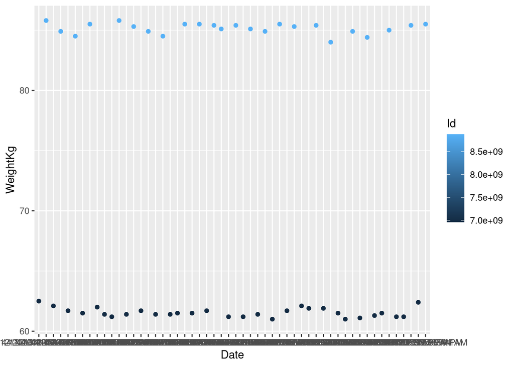

```r
ggplot(subset(weightinfo, Id %in% c("6962181067", "8877689391"))) + geom_point(aes(x=Date, y=WeightKg, color=Id))
```

As the date shown above, only two users’ weight information is recorded for a continuous period. Further more, there is no drastic fluctuation over time.